# Neighbourhood model (n = 2)

NodeBasedModels.jl vignette N11: SIS by the number of infected neighbours of each node, on a 3-regular network, against NetworkOutbreaks

## What this page shows

The neighbourhood model [Keeling, House, Cooper and Pellis 2016, *PLoS Comput. Biol.* 12:e1005296, approximation 3; compare the neighbourhood configuration model of Hadjichrysanthou et al. (2012)] classifies every node of a k-regular network by its own state and the number y of its k neighbours that are infected: [S_y] and [I_y], y = 0, …, k. A node’s own events are exact in these variables. The events of its neighbours need a closure, which at order n = 2 uses the states of pairs. This page:

1. builds the model from the Catalyst SIS model of `:sis_reg3` and with the direct constructor, and checks that the two are the same system;
2. writes out the equations and checks the numeric right-hand side against the independent symbolic builder;
3. checks the conservation laws along a solution;
4. compares the prevalence with the committed NetworkOutbreaks ensemble and with the pairwise model.

```julia
include(joinpath(@__DIR__, "..", "_shared", "setup.jl"))
require_summaries([:sis_reg3])
```

## The model, twice

```julia
using Catalyst, StableRNGs
sis = @reaction_network sis begin
    @parameters τ γ
    τ, S + I --> 2I        # contact: per-contact (per-edge) rate τ
    γ, I --> S             # recovery back into the susceptible class
end
model = contact_model(sis)
sc = scenario(:sis_reg3)            # 3-regular, τ = 1/2, γ = 1/4, 1% seeds in I, t ∈ [0, 80]
@assert isequivalent(model, sc.model)
ρ = last(only(sc.initial.fractions))
k = 3
nb  = node_based(model, sc.network; level = :neighbourhood, n = 2, p = sc.params,
                 initial = sc.initial, tspan = sc.tspan)                                      # low level
nbD = generate_neighbourhood(CompartmentalModel(model), k, 2; β = sc.params[:τ], γ = sc.params[:γ],
                             tspan = sc.tspan, ε = ρ)                                         # direct constructor
function max_rhs_gap(a, rhs_b; n = 25, seed = 1)
    rng = StableRNG(seed)
    d1, d2 = similar(a.u0), similar(a.u0)
    gap = 0.0
    for _ in 1:n
        u = a.u0 .* (0.2 .+ 1.6 .* rand(rng, length(a.u0))) .+ 1e-3 .* rand(rng, length(a.u0))
        a.rhs!(d1, u, a.params, 0.0)
        rhs_b(d2, u)
        gap = max(gap, maximum(abs.(d1 .- d2)))
    end
    return gap
end
(; variables = nb.var_names, u0_equal = nb.u0 == nbD.u0,
   max_rhs_gap = max_rhs_gap(nb, (du, u) -> nbD.rhs!(du, u, nbD.params, 0.0)))
```

```
(variables = [:S_0, :S_1, :S_2, :S_3, :I_0, :I_1, :I_2, :I_3], u0_equal = true, max_rhs_gap = 0.0)
```

The initial condition is random mixing: a fraction ρ = 0.01 of the nodes is infected independently, so the number of infected neighbours is Binomial(k, ρ) for every node.

## The equations

With per-contact rate τ and recovery rate γ, a node in [S_y] is infected at rate τy and a node in [I_y] recovers at rate γ. These events are the node’s own and need no closure. A neighbour of the node recovers at rate γ, which moves the node from y to y − 1. A susceptible neighbour of the node is infected at a rate that depends on that neighbour’s other neighbours. The n = 2 closure replaces it by its average over the pairs of the same type:

$$\omega_S = \tau\,\frac{\sum_y y\,(k-y)\,[S_y]}{\sum_y (k-y)\,[S_y]}, \qquad
\omega_I = \tau\,\frac{\sum_y y^2\,[S_y]}{\sum_y y\,[S_y]}.$$

Here ω_S is for a susceptible neighbour of an S node and ω_I for a susceptible neighbour of an I node. The model is

$$\begin{aligned}
\frac{d[S_y]}{dt} &= \gamma [I_y] - \tau y [S_y] + \gamma\big((y+1)[S_{y+1}] - y[S_y]\big)
+ \omega_S\big((k-y+1)[S_{y-1}] - (k-y)[S_y]\big),\\
\frac{d[I_y]}{dt} &= \tau y [S_y] - \gamma [I_y] + \gamma\big((y+1)[I_{y+1}] - y[I_y]\big)
+ \omega_I\big((k-y+1)[I_{y-1}] - (k-y)[I_y]\big),
\end{aligned}$$

with [S_{−1}] = [S_{k+1}] = 0 and the same for I. `build_neighbourhood_symbolic_rhs(k)` writes these equations with Symbolics from the paper’s equations, without calling the numeric builder. For k = 3, with the variables renamed:

```julia
rhs_sym!, keys_sym, exprs = build_neighbourhood_symbolic_rhs(k)
@assert [Symbol(X, :_, y) for (X, y) in keys_sym] == nb.var_names
pretty = Dict{Any,Any}(Symbolics.variable(Symbol("u_", i)) => Symbolics.variable(nb.var_names[i]) for i in eachindex(nb.var_names))
pretty[Symbolics.variable(:β_sym)] = Symbolics.variable(:τ)       # the builder names the per-contact rate β
pretty[Symbolics.variable(:γ_sym)] = Symbolics.variable(:γ)
for (i, e) in enumerate(exprs)
    println("d", nb.var_names[i], "/dt = ", Symbolics.substitute(e, pretty))
end
```

```
dS_0/dt = I_0*γ + S_1*γ - 3S_0*ifelse((3S_0 + 2S_1 + S_2) < 1.0e-12, 0, (2S_1 + 2S_2) / (3S_0 + 2S_1 + S_2))*τ
dS_1/dt = I_1*γ + (-S_1 + 2S_2)*γ - S_1*τ + (3S_0 - 2S_1)*ifelse((3S_0 + 2S_1 + S_2) < 1.0e-12, 0, (2S_1 + 2S_2) / (3S_0 + 2S_1 + S_2))*τ
dS_2/dt = I_2*γ + (-2S_2 + 3S_3)*γ - 2S_2*τ + (2S_1 - S_2)*ifelse((3S_0 + 2S_1 + S_2) < 1.0e-12, 0, (2S_1 + 2S_2) / (3S_0 + 2S_1 + S_2))*τ
dS_3/dt = I_3*γ - 3S_3*γ - 3S_3*τ + S_2*ifelse((3S_0 + 2S_1 + S_2) < 1.0e-12, 0, (2S_1 + 2S_2) / (3S_0 + 2S_1 + S_2))*τ
dI_0/dt = -I_0*γ + I_1*γ - 3I_0*ifelse((S_1 + 2S_2 + 3S_3) < 1.0e-12, 0, (S_1 + 4S_2 + 9S_3) / (S_1 + 2S_2 + 3S_3))*τ
dI_1/dt = (-I_1 + 2I_2)*γ - I_1*γ + S_1*τ + (3I_0 - 2I_1)*ifelse((S_1 + 2S_2 + 3S_3) < 1.0e-12, 0, (S_1 + 4S_2 + 9S_3) / (S_1 + 2S_2 + 3S_3))*τ
dI_2/dt = (-2I_2 + 3I_3)*γ - I_2*γ + 2S_2*τ + (2I_1 - I_2)*ifelse((S_1 + 2S_2 + 3S_3) < 1.0e-12, 0, (S_1 + 4S_2 + 9S_3) / (S_1 + 2S_2 + 3S_3))*τ
dI_3/dt = -4I_3*γ + 3S_3*τ + I_2*ifelse((S_1 + 2S_2 + 3S_3) < 1.0e-12, 0, (S_1 + 4S_2 + 9S_3) / (S_1 + 2S_2 + 3S_3))*τ
```

The `ifelse` guards the ratios where their denominators vanish. The numeric right-hand side agrees with the symbolic one:

```julia
(; max_gap_numeric_vs_symbolic = max_rhs_gap(nb, (du, u) -> rhs_sym!(du, u, (sc.params[:τ], sc.params[:γ]), 0.0)))
```

```
(max_gap_numeric_vs_symbolic = 6.938893903907228e-18,)
```

## Conservation laws

The node count is conserved, Σ_y([S_y] + [I_y]) = 1. Every SI edge is counted once from its S end and once from its I end, so Σ_y y[S_y] = Σ_y (k − y)[I_y] should hold as well. The closure must preserve this. Along the solution on the scenario grid:

```julia
sol = solve_neighbourhood(nb; saveat = sc.tgrid)
S(y) = [u[nb.index[(:S, y)]] for u in sol.u]
I(y) = [u[nb.index[(:I, y)]] for u in sol.u]
nodes  = sum(S(y) .+ I(y) for y in 0:k)
SI_S   = sum(y .* S(y) for y in 0:k)
SI_I   = sum((k - y) .* I(y) for y in 0:k)
(; max_node_defect = maximum(abs.(nodes .- 1)), max_SI_defect = maximum(abs.(SI_S .- SI_I)))
```

```
(max_node_defect = 1.1102230246251565e-15, max_SI_defect = 4.4797499043625066e-14)
```

## Against simulation

```julia
cnb = ModelCurves(sc.tgrid, Dict(:I => neighbourhood_compartment(nb, sol, :I), :S => neighbourhood_compartment(nb, sol, :S));
                  label = "neighbourhood n = 2", representation = :neighbourhood)
pw  = node_based(model, sc.network)                  # population pairwise, Bernoulli closure K = (k − 1)/k
cpw = model_curves(pw, solve_epidemic(pw, sc); t = sc.tgrid, label = "pairwise")
ref = scenario_summary(sc)
tab = compare(ref, cnb, cpw; observables = [:I])
```

```
ComparisonTable :sis_reg3  (scenario 485d890e; conditioned mean of 200 runs)
  curve                observable        D∞     t(D∞)       SE∞        z∞       ΔR∞  95% CI                 Δpeak   Δt_peak  coverage
  neighbourhood n = 2  I            0.02525     10.75   0.00160     21.41       NaN  [     NaN,      NaN]  -0.00106     42.25     0.769
  pairwise             I            0.14556      9.50   0.00160     93.69  14.70400  [14.70400, 14.70400]  -0.00023      2.00     0.153
```

```julia
describe_reference(ref);
```

```
NetworkOutbreaks reference :sis_reg3 (hash 485d890e): N = 10000 nodes, 200 runs on a fresh graph per run, algorithm :next_reaction; conditioning: surviving runs only (prevalence at t_end > 0); 200 of 200 runs kept (surviving runs), P(survival) = 1.000 (95% CI 0.981–1.000); no time alignment.
```

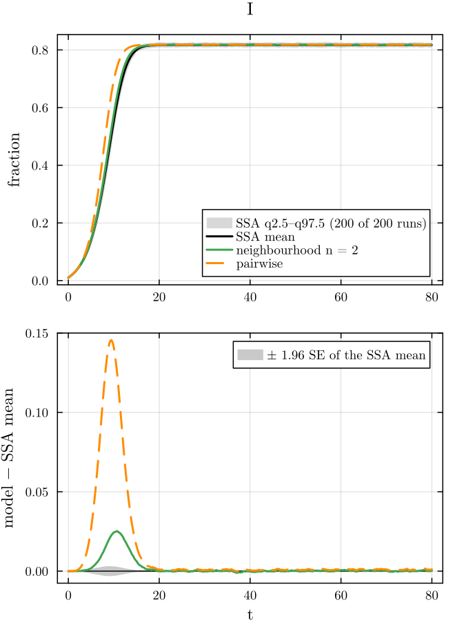

Neighbourhood model (n = 2) and pairwise model against the committed NetworkOutbreaks ensemble of `:sis_reg3`, conditioned on survival (spread band q2.5–q97.5 of the runs; residual panel: mean band ±1.96 SE).

```julia
distinct_styles!(comparisonplot(ref, cnb, cpw; observables = [:I]))
```

The neighbourhood model does not track cumulative incidence (ΔR∞ is NaN). The pairwise row’s ΔR∞ is its `:cumulative` at t = 80, which counts reinfections, minus the simulated fraction of nodes ever infected, so it is not a final-size error (page N09 explains this):

```julia
fs = ref.final_size[ref.major]
(; pairwise_cumulative_80 = cpw[:cumulative][end], mean_fraction_ever_infected = sum(fs) / length(fs),
   ΔR∞_pairwise = tab[cpw.label, :I].ΔR∞)
```

```
(pairwise_cumulative_80 = 15.704003220388449, mean_fraction_ever_infected = 1.0, ΔR∞_pairwise = 14.704003220388449)
```

The peak columns are not meaningful on an endemic plateau either. The largest gap and the endemic level:

```julia
st = ref.cond[:I]
md_table(["model", "variables", "D∞(I)", "t at D∞", "z∞", "I(80)", "I(80) − NO"],
         [(cnb.label, length(nb.var_names), tab[cnb.label, :I].D∞, tab[cnb.label, :I].t_D∞, tab[cnb.label, :I].z∞,
           cnb[:I][end], cnb[:I][end] - st.mean[end]),
          (cpw.label, length(pw.singles) + length(pw.pairs), tab[cpw.label, :I].D∞, tab[cpw.label, :I].t_D∞,
           tab[cpw.label, :I].z∞, cpw[:I][end], cpw[:I][end] - st.mean[end]),
          ("NetworkOutbreaks (mean ± SE)", "–", NaN, NaN, NaN, st.mean[end], st.se[end])])
```

| model | variables | D∞(I) | t at D∞ | z∞ | I(80) | I(80) − NO |
| --- | --- | --- | --- | --- | --- | --- |
| neighbourhood n = 2 | 8 | 0.02525 | 10.75 | 21.41 | 0.8173 | 0.0002934 |
| pairwise | 5 | 0.1456 | 9.5 | 93.69 | 0.8182 | 0.001126 |
| NetworkOutbreaks (mean ± SE) | – | NaN | NaN | NaN | 0.8171 | 0.0003 |

With 8 variables the neighbourhood model reduces the largest prevalence gap of the pairwise model from 0.1456 to 0.02525. Both approach the simulated endemic level: the endemic gaps are 0.0002934 and 0.001126, against a standard error of 0.0003. The model’s own output also includes the distribution of the number of infected neighbours. For example, at t = 80 a susceptible node has on average 2.237 infected neighbours:

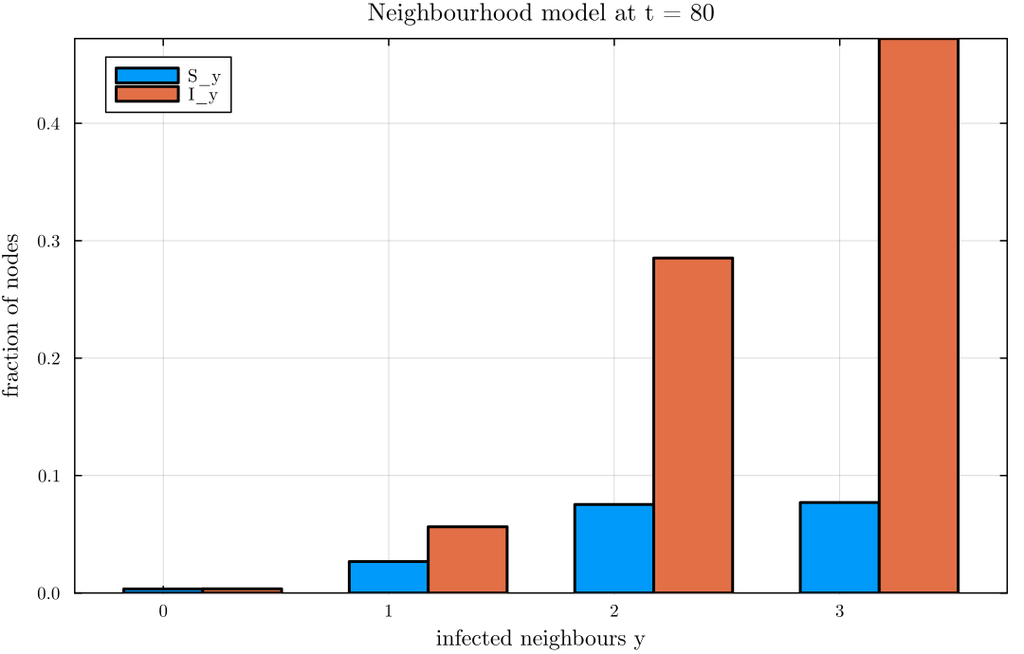

The neighbourhood distribution at t = 80: the fraction of all nodes in [S_y] and [I_y].

```julia
bar(0:k, [S(y)[end] for y in 0:k]; bar_width = 0.35, label = "S_y", xlabel = "infected neighbours y",
    ylabel = "fraction of nodes", title = "Neighbourhood model at t = 80")
bar!((0:k) .+ 0.35, [I(y)[end] for y in 0:k]; bar_width = 0.35, label = "I_y")
```

The neighbourhood distribution is a prediction of the model only. The committed summary does not store it, so it is not compared with the simulation here.

No Lean statement is involved on this page. Page N12 compares every SIS approximation.

## References

Hadjichrysanthou, Christoforos, Mark Broom, and István Z. Kiss. 2012. “Approximating Evolutionary Dynamics on Networks Using a Neighbourhood Configuration Model.” *Journal of Theoretical Biology* 312: 13–21. https://doi.org/10.1016/j.jtbi.2012.07.015.